# Income Inequality Before and After Taxes

Dorottya Zorka Csala

2025-12-10

```r
library(tidyverse)
knitr::opts_chunk$set(echo = TRUE)

theme_set(theme_light())
```

# Scraping data

```r
income_inequality <- read_csv( "https://raw.githubusercontent.com/rfordatascience/tidytuesday/main/data/2025/2025-08-05/income_inequality_processed.csv")
print(income_inequality)
```

```
## # A tibble: 947 × 5
##    Entity    Code   Year gini_mi_eq gini_dhi_eq
##    <chr>     <chr> <dbl>      <dbl>       <dbl>
##  1 Australia AUS    1989      0.431       0.304
##  2 Australia AUS    1995      0.47        0.311
##  3 Australia AUS    2001      0.481       0.32
##  4 Australia AUS    2003      0.469       0.316
##  5 Australia AUS    2004      0.467       0.316
##  6 Australia AUS    2008      0.469       0.335
##  7 Australia AUS    2010      0.47        0.333
##  8 Australia AUS    2014      0.481       0.329
##  9 Australia AUS    2016      0.467       0.326
## 10 Australia AUS    2018      0.469       0.329
## # ℹ 937 more rows
```

# Conducting exploratory data analysis: obtaining a basic summary of each variable and inspecting whether there are missing values

```r
glimpse(income_inequality)
```

```
## Rows: 947
## Columns: 5
## $ Entity      <chr> "Australia", "Australia", "Australia", "Australia", "Austr…
## $ Code        <chr> "AUS", "AUS", "AUS", "AUS", "AUS", "AUS", "AUS", "AUS", "A…
## $ Year        <dbl> 1989, 1995, 2001, 2003, 2004, 2008, 2010, 2014, 2016, 2018…
## $ gini_mi_eq  <dbl> 0.431, 0.470, 0.481, 0.469, 0.467, 0.469, 0.470, 0.481, 0.…
## $ gini_dhi_eq <dbl> 0.304, 0.311, 0.320, 0.316, 0.316, 0.335, 0.333, 0.329, 0.…
```

```r
summary(income_inequality)
```

```
##     Entity              Code                Year        gini_mi_eq
##  Length:947         Length:947         Min.   :1963   Min.   :0.3260
##  Class :character   Class :character   1st Qu.:1998   1st Qu.:0.4260
##  Mode  :character   Mode  :character   Median :2008   Median :0.4670
##                                        Mean   :2005   Mean   :0.4651
##                                        3rd Qu.:2015   3rd Qu.:0.5020
##                                        Max.   :2023   Max.   :0.7540
##                                                       NA's   :398
##   gini_dhi_eq
##  Min.   :0.1890
##  1st Qu.:0.2800
##  Median :0.3150
##  Mean   :0.3377
##  3rd Qu.:0.3670
##  Max.   :0.6640
##
```

```r
colSums(is.na(income_inequality))
```

```
##      Entity        Code        Year  gini_mi_eq gini_dhi_eq
##           0           0           0         398           0
```

# Creating reproducible plots

## Comparing distribution between Gini coefficient before and after tax

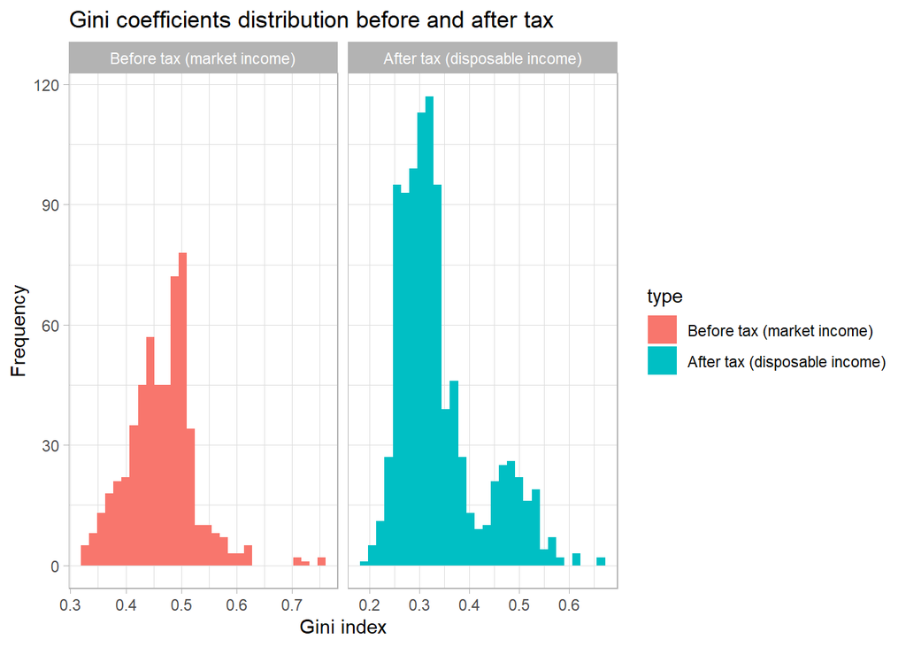

```r
income_inequality %>%
  pivot_longer(cols= c(gini_mi_eq, gini_dhi_eq), names_to= "type", values_to = "gini") %>%
   mutate(                               #I added this row, so in my plots the before tax condition will be the first and then the after tax condition. It helps understanding trends observed in the data more.
    type = factor(
      type,
      levels = c("gini_mi_eq", "gini_dhi_eq"),
      labels = c("Before tax (market income)", "After tax (disposable income)"))) %>%
    ggplot(aes(gini, fill= type)) + geom_histogram(bins= 30) +  facet_wrap(~ type, scales = "free_x") +
    labs(
    title = "Gini coefficients distribution before and after tax",
    x = "Gini index",
    y = "Frequency")
```

### Based on the histograms, Gini coefficient before tax is centered around 0.45-0.5, while Gini coefficient after tax is around 0.3-0.35, which is lower compared to the before tax condition. This shows that inequality reduces after tax. However, there are values that still remain high after taxes, which might stem from the country’s specific traits.

## Second research question I intend to find answer for is whether inequality both in before and after tax condition has decreased or increased overall throughout time.

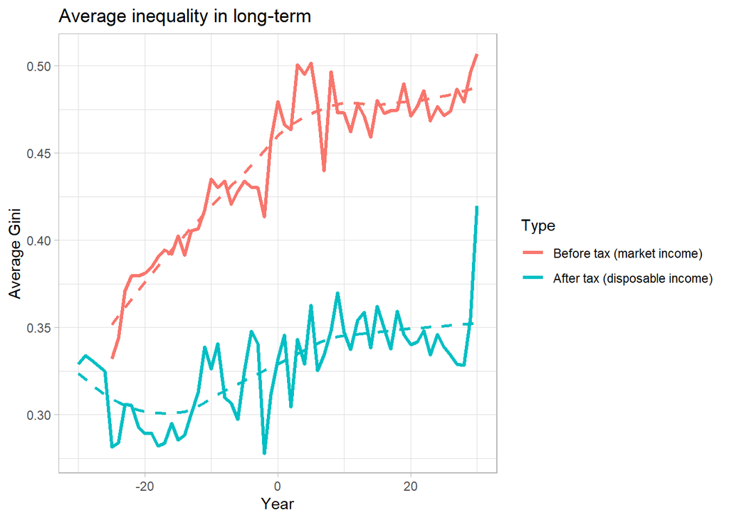

```r
income_inequality_cleaned <- income_inequality %>%
  group_by(Year) %>%
  summarise(
    before_tax = mean(gini_mi_eq, na.rm = TRUE),
    after_tax  = mean(gini_dhi_eq, na.rm = TRUE),
    .groups = "drop"
  ) %>%
  pivot_longer(                                    #From wide-format to long-format.
    cols = c(before_tax, after_tax),
    names_to = "type",
    values_to = "value"
  ) %>%
  mutate(                                           #I centered the year variable so it will be more interpretable.
    Year_c = Year - mean(Year, na.rm = TRUE),
    type = factor(
      type,
      levels = c("before_tax", "after_tax"),
      labels = c("Before tax (market income)", "After tax (disposable income)")
    )
  )

ggplot(income_inequality_cleaned, aes(x = Year_c, y = value, color = type)) +
  geom_line(linewidth = 1.2) +
  geom_smooth(method = "loess", se = FALSE, linetype = "dashed") +      #I added geom_smooth() so the overall trend could be better interpreted.
  labs(
    title = "Average inequality in long-term",
    y = "Average Gini",
    x = "Year",
    color = "Type"
  )
```

### In both conditions we could observe increase, though, the inequality before tax is still higher as opposed to the inequality after tax.

## My aim is to observe inequality trends for Belgium, Germany and United Kingdom both before tax and after tax condition.

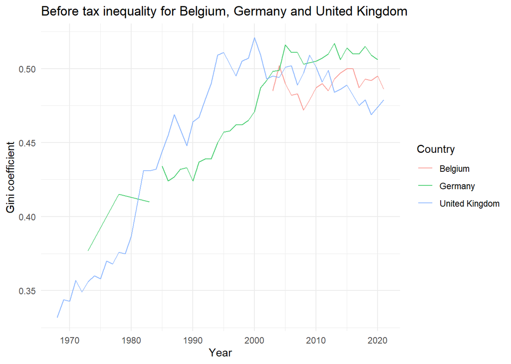

```r
income_inequality_cleaned_2 <- income_inequality %>%
  pivot_longer(
    cols = c(gini_mi_eq, gini_dhi_eq),
    names_to = "type",
    values_to = "gini"
  ) %>%
  mutate(
    type = factor(
      type,
      levels = c("gini_mi_eq", "gini_dhi_eq"),
      labels = c("Before tax (market income)", "After tax (disposable income)")
    )
  )

countries <- c("Belgium", "Germany", "United Kingdom")

income_inequality_cleaned_2 %>% filter(type == "Before tax (market income)", Entity %in% countries) %>%
  ggplot(aes(x = Year, y = gini, color = Entity)) +
  geom_line(alpha = 0.7) +
  labs(
    title = "Before tax inequality for Belgium, Germany and United Kingdom",
    y = "Gini coefficient",
    x = "Year",
    color = "Country"
  ) +
  theme_minimal()
```

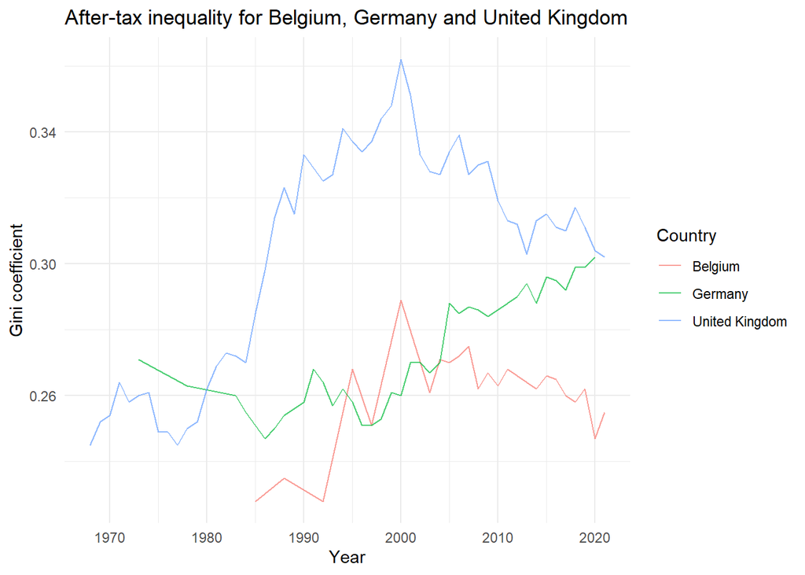

```r
income_inequality_cleaned_2 %>%  filter(type == "After tax (disposable income)", Entity %in% countries) %>%
  ggplot(aes(x = Year, y = gini, color = Entity)) +
  geom_line(alpha = 0.7) +
  labs(
    title = "After-tax inequality for Belgium, Germany and United Kingdom",
    y = "Gini coefficient",
    x = "Year",
    color = "Country"
  ) +
  theme_minimal()
```

### Based on the plots, we can conclude that there were missing data in our dataset, as we did not get a continuous line. Neither Germany nor Belgium have early inequality data as opposed to United Kingdom.

# My hypothesis is that year can predict Gini coefficient before tax. To investigate my hypothesis, I am going to build a linear model.

```r
library(sjPlot)
library(performance)
library(see)
income_inequality <- income_inequality %>%
  mutate(Year_c = Year - mean(Year, na.rm = TRUE))

lm_before <- lm(gini_mi_eq ~ Year_c, data = income_inequality)
summary(lm_before)
```

```
##
## Call:
## lm(formula = gini_mi_eq ~ Year_c, data = income_inequality)
##
## Residuals:
##       Min        1Q    Median        3Q       Max
## -0.158937 -0.031171  0.003602  0.027176  0.284637
##
## Coefficients:
##             Estimate Std. Error t value Pr(>|t|)
## (Intercept) 0.464837   0.002446 190.061   <2e-16 ***
## Year_c      0.001730   0.000197   8.784   <2e-16 ***
## ---
## Signif. codes:  0 '***' 0.001 '**' 0.01 '*' 0.05 '.' 0.1 ' ' 1
##
## Residual standard error: 0.0573 on 547 degrees of freedom
##   (398 observations deleted due to missingness)
## Multiple R-squared:  0.1236, Adjusted R-squared:  0.122
## F-statistic: 77.16 on 1 and 547 DF,  p-value: < 2.2e-16
```

```r
tab_model(lm_before)
```

|  | gini_mi_eq |  |  |
| --- | --- | --- | --- |
| Predictors | Estimates | CI | p |
| (Intercept) | 0.46 | 0.46 – 0.47 | **<0.001** |
| Year c | 0.00 | 0.00 – 0.00 | **<0.001** |
| Observations | 549 |  |  |
| R<sup>2</sup> / R<sup>2</sup> adjusted | 0.124 / 0.122 |  |  |

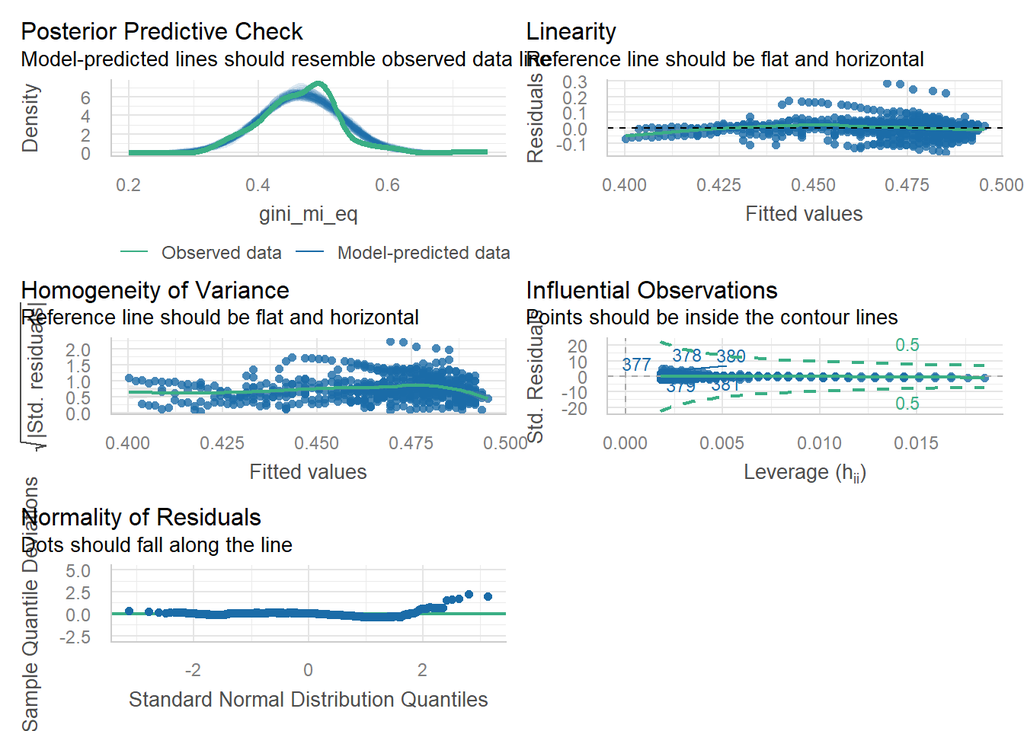

```r
check_model(lm_before)
```

## The results showed that the intercept is significantly different from zero. The estimate of Year was also significant with a value of zero which detects a consistent trend across years, though, it is very small. The value of adjusted R2 is 0.12, which shows that the model explains only 12.2% variance in gini_mi_eq.

### I could observe mild deviation,especially on the right tail of the plot, though it is not severe, so the assumption of linearity is met.

### The homogeneity of variance plot shows mild heteroscedasticity, though, I could not observe a specific, e.g., funnel-shape.

### Regarding influential cases, there are some outliers, such as points 378, 380, 381.

### Based on the last plot, I can observe a heavy-tail on the right end, so it suggests that the residuals are not perfectly normally distributed.

# For the next model, I will add Entity as predictor as well to my previous model and see if it improves prediction.

```r
library(sjPlot)
library(performance)
library(see)

lm_before_and_country <- lm(gini_mi_eq ~ Year_c + Entity, data = income_inequality)
summary(lm_before_and_country)
```

```
##
## Call:
## lm(formula = gini_mi_eq ~ Year_c + Entity, data = income_inequality)
##
## Residuals:
##       Min        1Q    Median        3Q       Max
## -0.072960 -0.014274 -0.000217  0.014059  0.074238
##
## Coefficients:
##                            Estimate Std. Error t value Pr(>|t|)
## (Intercept)               4.636e-01  7.166e-03  64.700  < 2e-16 ***
## Year_c                    1.770e-03  9.811e-05  18.043  < 2e-16 ***
## EntityAustria             1.244e-02  8.934e-03   1.392 0.164461
## EntityBelgium             1.510e-02  8.849e-03   1.706 0.088519 .
## EntityBrazil              1.269e-01  8.849e-03  14.339  < 2e-16 ***
## EntityBulgaria            1.687e-02  9.334e-03   1.808 0.071239 .
## EntityCanada             -3.012e-02  8.036e-03  -3.748 0.000199 ***
## EntityCzechia            -1.259e-02  1.206e-02  -1.044 0.296870
## EntityDenmark            -1.653e-02  9.309e-03  -1.776 0.076367 .
## EntityDominican Republic  5.652e-02  2.482e-02   2.278 0.023146 *
## EntityEstonia             7.414e-03  1.282e-02   0.578 0.563240
## EntityFinland            -8.361e-02  1.069e-02  -7.822 2.93e-14 ***
## EntityGermany             1.780e-02  8.136e-03   2.188 0.029122 *
## EntityGreece              3.539e-02  9.327e-03   3.795 0.000165 ***
## EntityIceland            -1.215e-01  9.436e-03 -12.879  < 2e-16 ***
## EntityIreland             5.810e-02  8.849e-03   6.566 1.26e-10 ***
## EntityIsrael              7.336e-03  8.596e-03   0.853 0.393812
## EntityItaly               7.008e-02  1.550e-02   4.520 7.66e-06 ***
## EntityJapan              -6.264e-02  9.757e-03  -6.420 3.09e-10 ***
## EntityLithuania           3.429e-02  9.764e-03   3.511 0.000485 ***
## EntityLuxembourg         -5.649e-03  9.010e-03  -0.627 0.530922
## EntityNetherlands        -4.423e-02  8.710e-03  -5.078 5.33e-07 ***
## EntityNorway             -4.681e-02  1.214e-02  -3.855 0.000130 ***
## EntityRomania            -1.449e-02  1.553e-02  -0.933 0.351208
## EntitySlovakia           -6.751e-02  1.069e-02  -6.313 5.88e-10 ***
## EntitySouth Africa        2.548e-01  1.283e-02  19.864  < 2e-16 ***
## EntitySpain               1.848e-02  9.020e-03   2.049 0.040966 *
## EntitySweden             -2.291e-02  8.714e-03  -2.629 0.008806 **
## EntitySwitzerland        -9.258e-02  9.002e-03 -10.284  < 2e-16 ***
## EntityUnited Kingdom      7.522e-03  7.956e-03   0.946 0.344838
## EntityUnited States       2.168e-02  7.934e-03   2.732 0.006513 **
## ---
## Signif. codes:  0 '***' 0.001 '**' 0.01 '*' 0.05 '.' 0.1 ' ' 1
##
## Residual standard error: 0.02376 on 518 degrees of freedom
##   (398 observations deleted due to missingness)
## Multiple R-squared:  0.8573, Adjusted R-squared:  0.8491
## F-statistic: 103.7 on 30 and 518 DF,  p-value: < 2.2e-16
```

```r
tab_model(lm_before_and_country)
```

|  | gini_mi_eq |  |  |
| --- | --- | --- | --- |
| Predictors | Estimates | CI | p |
| (Intercept) | 0.46 | 0.45 – 0.48 | **<0.001** |
| Year c | 0.00 | 0.00 – 0.00 | **<0.001** |
| Entity [Austria] | 0.01 | -0.01 – 0.03 | 0.164 |
| Entity [Belgium] | 0.02 | -0.00 – 0.03 | 0.089 |
| Entity [Brazil] | 0.13 | 0.11 – 0.14 | **<0.001** |
| Entity [Bulgaria] | 0.02 | -0.00 – 0.04 | 0.071 |
| Entity [Canada] | -0.03 | -0.05 – -0.01 | **<0.001** |
| Entity [Czechia] | -0.01 | -0.04 – 0.01 | 0.297 |
| Entity [Denmark] | -0.02 | -0.03 – 0.00 | 0.076 |
| Entity [Dominican Republic] | 0.06 | 0.01 – 0.11 | **0.023** |
| Entity [Estonia] | 0.01 | -0.02 – 0.03 | 0.563 |
| Entity [Finland] | -0.08 | -0.10 – -0.06 | **<0.001** |
| Entity [Germany] | 0.02 | 0.00 – 0.03 | **0.029** |
| Entity [Greece] | 0.04 | 0.02 – 0.05 | **<0.001** |
| Entity [Iceland] | -0.12 | -0.14 – -0.10 | **<0.001** |
| Entity [Ireland] | 0.06 | 0.04 – 0.08 | **<0.001** |
| Entity [Israel] | 0.01 | -0.01 – 0.02 | 0.394 |
| Entity [Italy] | 0.07 | 0.04 – 0.10 | **<0.001** |
| Entity [Japan] | -0.06 | -0.08 – -0.04 | **<0.001** |
| Entity [Lithuania] | 0.03 | 0.02 – 0.05 | **<0.001** |
| Entity [Luxembourg] | -0.01 | -0.02 – 0.01 | 0.531 |
| Entity [Netherlands] | -0.04 | -0.06 – -0.03 | **<0.001** |
| Entity [Norway] | -0.05 | -0.07 – -0.02 | **<0.001** |
| Entity [Romania] | -0.01 | -0.04 – 0.02 | 0.351 |
| Entity [Slovakia] | -0.07 | -0.09 – -0.05 | **<0.001** |
| Entity [South Africa] | 0.25 | 0.23 – 0.28 | **<0.001** |
| Entity [Spain] | 0.02 | 0.00 – 0.04 | **0.041** |
| Entity [Sweden] | -0.02 | -0.04 – -0.01 | **0.009** |
| Entity [Switzerland] | -0.09 | -0.11 – -0.07 | **<0.001** |
| Entity [United Kingdom] | 0.01 | -0.01 – 0.02 | 0.345 |
| Entity [United States] | 0.02 | 0.01 – 0.04 | **0.007** |
| Observations | 549 |  |  |
| R<sup>2</sup> / R<sup>2</sup> adjusted | 0.857 / 0.849 |  |  |

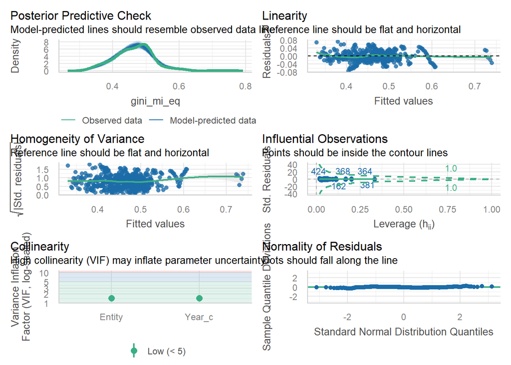

```r
check_model(lm_before_and_country)
```

### The scatter plot of residuals appears to be relatively flat and centered around zero, so the assumption of linearity is met.

### The homogeneity of variance plot shows mild heteroscedasticity, though, I could not observe a specific, e.g., funnel-shape.

### Based on the plot, there are some influential cases that have high residuals, such as points 381, 424.

### Based on the VIF values, predictors are not highly correlated.

### The normality of residuals is met.

# Now I will compare the two models I built.

```r
anova(lm_before, lm_before_and_country)
```

```
## Analysis of Variance Table
##
## Model 1: gini_mi_eq ~ Year_c
## Model 2: gini_mi_eq ~ Year_c + Entity
##   Res.Df     RSS Df Sum of Sq      F    Pr(>F)
## 1    547 1.79596
## 2    518 0.29241 29    1.5035 91.846 < 2.2e-16 ***
## ---
## Signif. codes:  0 '***' 0.001 '**' 0.01 '*' 0.05 '.' 0.1 ' ' 1
```

## Adding Entity to our model significantly improves the second model.

# Now I will build the same models for after tax condition and also compare them.

```r
lm_after <- lm(gini_dhi_eq ~ Year_c, data = income_inequality)
summary(lm_after)
```

```
##
## Call:
## lm(formula = gini_dhi_eq ~ Year_c, data = income_inequality)
##
## Residuals:
##      Min       1Q   Median       3Q      Max
## -0.13749 -0.06049 -0.02140  0.02611  0.32244
##
## Coefficients:
##              Estimate Std. Error t value Pr(>|t|)
## (Intercept) 0.3376980  0.0026798 126.015  < 2e-16 ***
## Year_c      0.0008371  0.0002149   3.895 0.000105 ***
## ---
## Signif. codes:  0 '***' 0.001 '**' 0.01 '*' 0.05 '.' 0.1 ' ' 1
##
## Residual standard error: 0.08247 on 945 degrees of freedom
## Multiple R-squared:  0.0158, Adjusted R-squared:  0.01476
## F-statistic: 15.17 on 1 and 945 DF,  p-value: 0.0001051
```

```r
tab_model(lm_after)
```

|  | gini_dhi_eq |  |  |
| --- | --- | --- | --- |
| Predictors | Estimates | CI | p |
| (Intercept) | 0.34 | 0.33 – 0.34 | **<0.001** |
| Year c | 0.00 | 0.00 – 0.00 | **<0.001** |
| Observations | 947 |  |  |
| R<sup>2</sup> / R<sup>2</sup> adjusted | 0.016 / 0.015 |  |  |

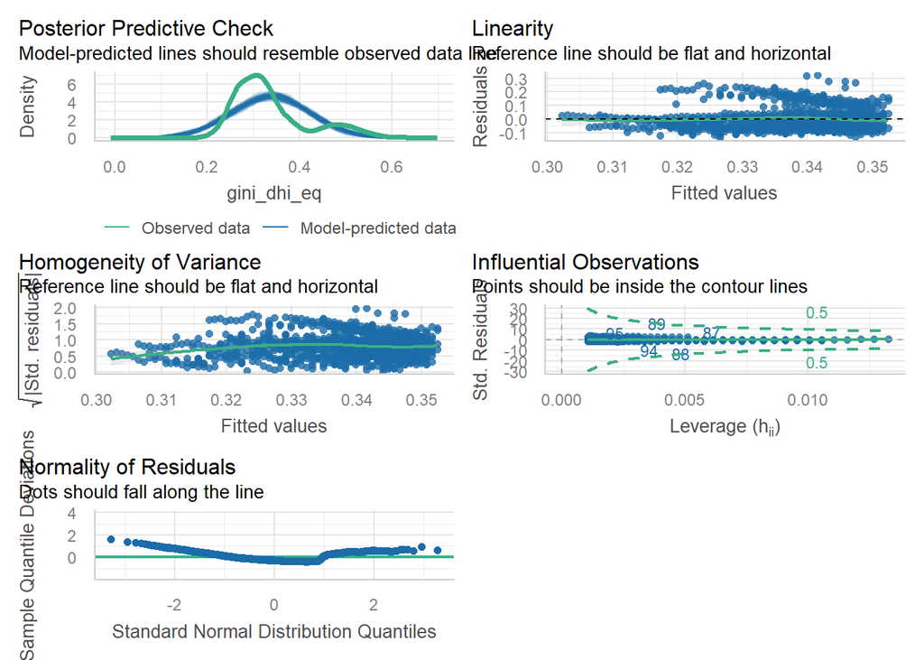

```r
check_model(lm_after)
```

```r
lm_after_and_country <- lm(gini_dhi_eq ~ Year_c + Entity, data = income_inequality)
summary(lm_after_and_country)
```

```
##
## Call:
## lm(formula = gini_dhi_eq ~ Year_c + Entity, data = income_inequality)
##
## Residuals:
##       Min        1Q    Median        3Q       Max
## -0.072843 -0.013678  0.000717  0.012801  0.089897
##
## Coefficients:
##                            Estimate Std. Error t value Pr(>|t|)
## (Intercept)               3.177e-01  6.403e-03  49.626  < 2e-16 ***
## Year_c                    4.462e-04  7.014e-05   6.362 3.17e-10 ***
## EntityAustria            -4.549e-02  7.799e-03  -5.833 7.62e-09 ***
## EntityBelgium            -5.812e-02  7.897e-03  -7.360 4.18e-13 ***
## EntityBrazil              1.953e-01  7.416e-03  26.328  < 2e-16 ***
## EntityBulgaria            4.626e-02  8.653e-03   5.346 1.14e-07 ***
## EntityCanada             -9.716e-03  7.275e-03  -1.335 0.182055
## EntityChile               1.722e-01  9.052e-03  19.017  < 2e-16 ***
## EntityChina               8.876e-02  1.479e-02   6.000 2.86e-09 ***
## EntityColombia            1.787e-01  8.031e-03  22.246  < 2e-16 ***
## EntityCote d'Ivoire       2.419e-01  1.479e-02  16.362  < 2e-16 ***
## EntityCzechia            -6.682e-02  1.037e-02  -6.442 1.92e-10 ***
## EntityDenmark            -6.019e-02  8.629e-03  -6.975 5.96e-12 ***
## EntityDominican Republic  1.965e-01  2.395e-02   8.206 7.96e-16 ***
## EntityEstonia             1.661e-02  1.140e-02   1.458 0.145270
## EntityFinland            -7.225e-02  1.001e-02  -7.220 1.11e-12 ***
## EntityFrance             -1.859e-02  7.663e-03  -2.426 0.015453 *
## EntityGeorgia             7.539e-02  8.930e-03   8.442  < 2e-16 ***
## EntityGermany            -4.328e-02  7.372e-03  -5.871 6.12e-09 ***
## EntityGreece              7.055e-03  8.088e-03   0.872 0.383292
## EntityGuatemala           1.527e-01  1.479e-02  10.325  < 2e-16 ***
## EntityHungary            -3.012e-02  1.037e-02  -2.904 0.003771 **
## EntityIceland            -4.853e-02  8.758e-03  -5.541 3.95e-08 ***
## EntityIndia               1.768e-01  1.753e-02  10.085  < 2e-16 ***
## EntityIreland            -9.981e-03  7.899e-03  -1.264 0.206673
## EntityIsrael              3.524e-02  7.897e-03   4.463 9.12e-06 ***
## EntityItaly               6.215e-03  7.914e-03   0.785 0.432431
## EntityJapan              -1.889e-02  9.083e-03  -2.080 0.037830 *
## EntityLithuania           3.443e-02  9.089e-03   3.788 0.000162 ***
## EntityLuxembourg         -4.794e-02  7.441e-03  -6.443 1.91e-10 ***
```

[output cut: 14 more lines]

```
## EntitySouth Africa        3.155e-01  1.216e-02  25.945  < 2e-16 ***
## EntitySouth Korea         4.133e-03  9.488e-03   0.436 0.663230
## EntitySpain               1.391e-02  7.665e-03   1.815 0.069925 .
## EntitySweden             -6.000e-02  7.793e-03  -7.699 3.64e-14 ***
## EntitySwitzerland        -2.240e-02  8.314e-03  -2.694 0.007193 **
## EntityUnited Kingdom     -9.789e-03  7.157e-03  -1.368 0.171750
## EntityUnited States       4.205e-02  7.088e-03   5.933 4.26e-09 ***
## EntityUruguay             7.190e-02  8.525e-03   8.434  < 2e-16 ***
## EntityVietnam             5.705e-02  1.215e-02   4.695 3.09e-06 ***
## ---
## Signif. codes:  0 '***' 0.001 '**' 0.01 '*' 0.05 '.' 0.1 ' ' 1
##
## Residual standard error: 0.02308 on 894 degrees of freedom
## Multiple R-squared:  0.9271, Adjusted R-squared:  0.9228
## F-statistic: 218.6 on 52 and 894 DF,  p-value: < 2.2e-16
```

```r
tab_model(lm_after_and_country)
```

|  | gini_dhi_eq |  |  |
| --- | --- | --- | --- |
| Predictors | Estimates | CI | p |
| (Intercept) | 0.32 | 0.31 – 0.33 | **<0.001** |
| Year c | 0.00 | 0.00 – 0.00 | **<0.001** |
| Entity [Austria] | -0.05 | -0.06 – -0.03 | **<0.001** |
| Entity [Belgium] | -0.06 | -0.07 – -0.04 | **<0.001** |
| Entity [Brazil] | 0.20 | 0.18 – 0.21 | **<0.001** |
| Entity [Bulgaria] | 0.05 | 0.03 – 0.06 | **<0.001** |
| Entity [Canada] | -0.01 | -0.02 – 0.00 | 0.182 |
| Entity [Chile] | 0.17 | 0.15 – 0.19 | **<0.001** |
| Entity [China] | 0.09 | 0.06 – 0.12 | **<0.001** |
| Entity [Colombia] | 0.18 | 0.16 – 0.19 | **<0.001** |
| Entity [Cote d’Ivoire] | 0.24 | 0.21 – 0.27 | **<0.001** |
| Entity [Czechia] | -0.07 | -0.09 – -0.05 | **<0.001** |
| Entity [Denmark] | -0.06 | -0.08 – -0.04 | **<0.001** |
| Entity [Dominican Republic] | 0.20 | 0.15 – 0.24 | **<0.001** |
| Entity [Estonia] | 0.02 | -0.01 – 0.04 | 0.145 |
| Entity [Finland] | -0.07 | -0.09 – -0.05 | **<0.001** |
| Entity [France] | -0.02 | -0.03 – -0.00 | **0.015** |
| Entity [Georgia] | 0.08 | 0.06 – 0.09 | **<0.001** |
| Entity [Germany] | -0.04 | -0.06 – -0.03 | **<0.001** |
| Entity [Greece] | 0.01 | -0.01 – 0.02 | 0.383 |
| Entity [Guatemala] | 0.15 | 0.12 – 0.18 | **<0.001** |
| Entity [Hungary] | -0.03 | -0.05 – -0.01 | **0.004** |
| Entity [Iceland] | -0.05 | -0.07 – -0.03 | **<0.001** |
| Entity [India] | 0.18 | 0.14 – 0.21 | **<0.001** |
| Entity [Ireland] | -0.01 | -0.03 – 0.01 | 0.207 |
| Entity [Israel] | 0.04 | 0.02 – 0.05 | **<0.001** |
| Entity [Italy] | 0.01 | -0.01 – 0.02 | 0.432 |
| Entity [Japan] | -0.02 | -0.04 – -0.00 | **0.038** |
| Entity [Lithuania] | 0.03 | 0.02 – 0.05 | **<0.001** |
| Entity [Luxembourg] | -0.05 | -0.06 – -0.03 | **<0.001** |
| Entity [Mali] | 0.05 | 0.03 – 0.07 | **<0.001** |
| Entity [Mexico] | 0.15 | 0.13 – 0.16 | **<0.001** |
| Entity [Netherlands] | -0.05 | -0.07 – -0.04 | **<0.001** |
| Entity [Norway] | -0.07 | -0.08 – -0.05 | **<0.001** |
| Entity [Palestine] | 0.13 | 0.10 – 0.17 | **<0.001** |
| Entity [Panama] | 0.15 | 0.13 – 0.18 | **<0.001** |
| Entity [Paraguay] | 0.18 | 0.16 – 0.20 | **<0.001** |
| Entity [Peru] | 0.15 | 0.14 – 0.17 | **<0.001** |
| Entity [Poland] | -0.02 | -0.04 – -0.00 | **0.011** |
| Entity [Romania] | -0.01 | -0.03 – 0.01 | 0.188 |
| Entity [Russia] | 0.02 | 0.00 – 0.04 | **0.015** |
| Entity [Serbia] | 0.01 | -0.01 – 0.02 | 0.455 |
| Entity [Slovakia] | -0.08 | -0.09 – -0.06 | **<0.001** |
| Entity [Slovenia] | -0.07 | -0.10 – -0.05 | **<0.001** |
| Entity [South Africa] | 0.32 | 0.29 – 0.34 | **<0.001** |
| Entity [South Korea] | 0.00 | -0.01 – 0.02 | 0.663 |
| Entity [Spain] | 0.01 | -0.00 – 0.03 | 0.070 |
| Entity [Sweden] | -0.06 | -0.08 – -0.04 | **<0.001** |
| Entity [Switzerland] | -0.02 | -0.04 – -0.01 | **0.007** |
| Entity [United Kingdom] | -0.01 | -0.02 – 0.00 | 0.172 |
| Entity [United States] | 0.04 | 0.03 – 0.06 | **<0.001** |
| Entity [Uruguay] | 0.07 | 0.06 – 0.09 | **<0.001** |
| Entity [Vietnam] | 0.06 | 0.03 – 0.08 | **<0.001** |
| Observations | 947 |  |  |
| R<sup>2</sup> / R<sup>2</sup> adjusted | 0.927 / 0.923 |  |  |

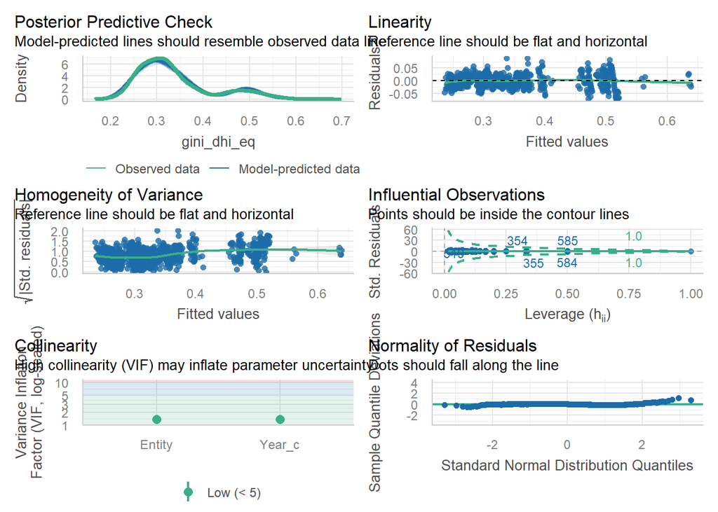

```r
check_model(lm_after_and_country)
```

```r
anova(lm_after_and_country)
```

```
## Analysis of Variance Table
##
## Response: gini_dhi_eq
##            Df Sum Sq  Mean Sq F value    Pr(>F)
## Year_c      1 0.1032 0.103178  193.70 < 2.2e-16 ***
## Entity     51 5.9506 0.116679  219.05 < 2.2e-16 ***
## Residuals 894 0.4762 0.000533
## ---
## Signif. codes:  0 '***' 0.001 '**' 0.01 '*' 0.05 '.' 0.1 ' ' 1
```

## For the after tax condition, I can conclude the same results: year has a significant, but small effect. Adding countries (Entity variable) to the model improves the model. The adjusted R2 is 0.92, which shows that the second model containing year and countries explains 92% of variance in gini_dhi_eq.

### However, the assumption checks are not perfectly met in either of the model: in both models, residuals are not linearly distributed and I could observe heteroscedasticity as well. There are influential cases as well in the dataset. Furthermore, the normality of residuals in the first model is not met as it has heavy tails both on the right and left ends, but the normality of residuals is met in the second model.